# Homework2_Sampling

Brianna Shaughnessy

9/10/2018

## 1. R Warmup

#### 1a. Create a vector of 100 randomly distributed numbers between 0 and 100 using runif and save the vector into the variable my_vec. If you cannot figure out runif, try ?runif.

```r
my_vec <- runif(n = 100, min = 0, max = 100)
my_vec
```

```
##   [1] 91.2137482 20.0438449 45.6561036 57.6651735 72.1285549 35.9576883
##   [7] 73.3760183 74.2552354 72.1653723 15.9283299 52.4099429  6.2425574
##  [13] 85.3958202  2.6718560  6.9815528 57.4169119  7.2720851 62.1513305
##  [19] 63.1976125 70.3741257 33.9278833  4.5502776 56.6965928 91.1995803
##  [25] 40.4835133 36.7575577 96.0023890 91.6043358 74.6714595 80.1404417
##  [31] 97.1058789 62.3992611 56.6945687 32.9402237 80.2445167 46.4552655
##  [37] 72.3247362 77.5821609 44.0165434 45.9190807 10.6879508 84.4182922
##  [43] 53.0963687 15.3569429 83.1270630 29.7997159 87.4069974 28.9856206
##  [49] 13.8954667  5.2161459 26.4234430 83.1834313 53.7010488 74.2879578
##  [55] 40.4457328  1.9638338 35.0395195 86.3069414 15.7995970 18.4694894
##  [61] 89.2840439 23.6711490 72.5108741 10.2961627 66.1669479 21.0222351
##  [67] 91.0305212 29.0604379 36.6747559 52.1669435 69.8045630 52.0467050
##  [73] 90.8984567 19.4765474 46.0192921  7.9349270 13.4313335 93.0292120
##  [79]  2.3951522 68.8030030 32.7974734 36.1516184 29.1145192  7.0823884
##  [85] 12.8603974 92.4403299 28.4033836 51.7265838 48.1976620 73.9403316
##  [91] 44.7365785  0.4736404  9.6644660 77.7554307 82.2873613 87.2468848
##  [97] 69.2145509 35.2999162 90.5263803 59.4938197
```

```r
str(my_vec)
```

```
##  num [1:100] 91.2 20 45.7 57.7 72.1 ...
```

```r
summary(my_vec)
```

```
##    Min. 1st Qu.  Median    Mean 3rd Qu.    Max.
##  0.4736 25.7354 51.8866 49.6697 74.2634 97.1059
```

#### What information does str and summary tell you about my_vec? How do they differ?

**str(my_vec)** tells us that this vector is a set of numeric values. It gives us a sample of values from the vector and tells us the vector size is [1:100] meaning 1 row and 100 columns.  
**summary(my_vec)** gives us descriptive information about the vector including is 4 quartiles, Median, and Mean.

#### 1b. Try out a little plot. What does hist(my_vec) show you? What information does the helpfile for hist tell you about what you just did?

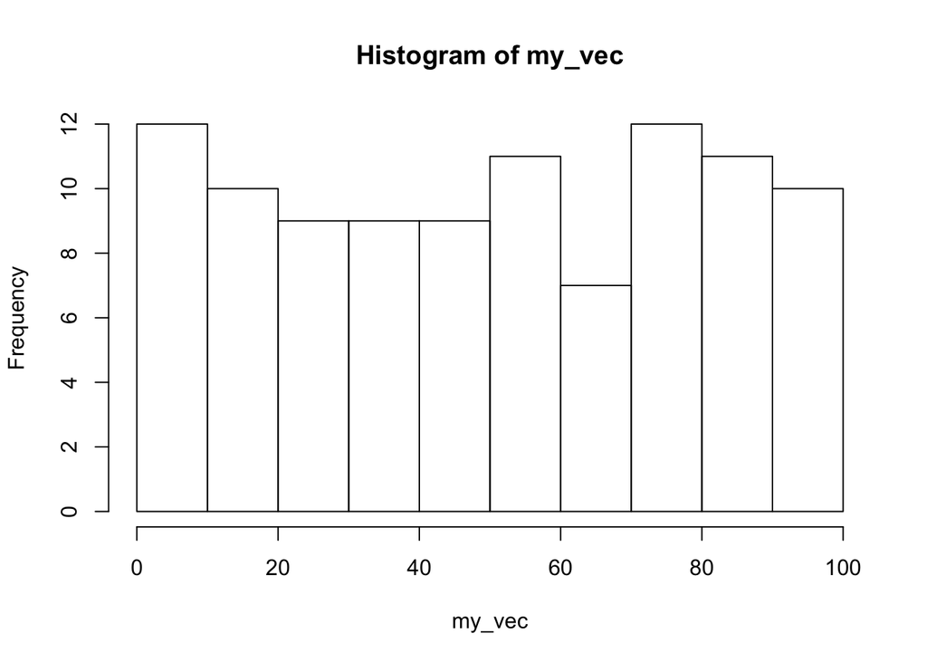

```r
hist(my_vec)
```

**hist(my_vec)** shows a histrogram of the distribution of numbers in the vector I created. In other words - the frequency of each number between 1 and 100 in our randomly chosen dataset. The helpfile for hist describes the use of the generic function hist and gives detailed explanation of the Arguments used in the function and examples of how to use it for different applications.

#### 1c. Load up the mtcars dataset using data(mtcars). Apply the following functions to mtcars: class, str, summary. What do these three functions tell you about mtcars?

```r
data("mtcars")
class(mtcars)
```

```
## [1] "data.frame"
```

```r
str(mtcars)
```

```
## 'data.frame':    32 obs. of  11 variables:
##  $ mpg : num  21 21 22.8 21.4 18.7 18.1 14.3 24.4 22.8 19.2 ...
##  $ cyl : num  6 6 4 6 8 6 8 4 4 6 ...
##  $ disp: num  160 160 108 258 360 ...
##  $ hp  : num  110 110 93 110 175 105 245 62 95 123 ...
##  $ drat: num  3.9 3.9 3.85 3.08 3.15 2.76 3.21 3.69 3.92 3.92 ...
##  $ wt  : num  2.62 2.88 2.32 3.21 3.44 ...
##  $ qsec: num  16.5 17 18.6 19.4 17 ...
##  $ vs  : num  0 0 1 1 0 1 0 1 1 1 ...
##  $ am  : num  1 1 1 0 0 0 0 0 0 0 ...
##  $ gear: num  4 4 4 3 3 3 3 4 4 4 ...
##  $ carb: num  4 4 1 1 2 1 4 2 2 4 ...
```

```r
summary(mtcars)
```

```
##       mpg             cyl             disp             hp
##  Min.   :10.40   Min.   :4.000   Min.   : 71.1   Min.   : 52.0
##  1st Qu.:15.43   1st Qu.:4.000   1st Qu.:120.8   1st Qu.: 96.5
##  Median :19.20   Median :6.000   Median :196.3   Median :123.0
##  Mean   :20.09   Mean   :6.188   Mean   :230.7   Mean   :146.7
##  3rd Qu.:22.80   3rd Qu.:8.000   3rd Qu.:326.0   3rd Qu.:180.0
##  Max.   :33.90   Max.   :8.000   Max.   :472.0   Max.   :335.0
##       drat             wt             qsec             vs
##  Min.   :2.760   Min.   :1.513   Min.   :14.50   Min.   :0.0000
##  1st Qu.:3.080   1st Qu.:2.581   1st Qu.:16.89   1st Qu.:0.0000
##  Median :3.695   Median :3.325   Median :17.71   Median :0.0000
##  Mean   :3.597   Mean   :3.217   Mean   :17.85   Mean   :0.4375
##  3rd Qu.:3.920   3rd Qu.:3.610   3rd Qu.:18.90   3rd Qu.:1.0000
##  Max.   :4.930   Max.   :5.424   Max.   :22.90   Max.   :1.0000
##        am              gear            carb
##  Min.   :0.0000   Min.   :3.000   Min.   :1.000
##  1st Qu.:0.0000   1st Qu.:3.000   1st Qu.:2.000
##  Median :0.0000   Median :4.000   Median :2.000
##  Mean   :0.4062   Mean   :3.688   Mean   :2.812
##  3rd Qu.:1.0000   3rd Qu.:4.000   3rd Qu.:4.000
##  Max.   :1.0000   Max.   :5.000   Max.   :8.000
```

**The class function** tells us that mtcars is a data frame from R  
**The structure** function gives us a bit more information about the mtcars dataframe, letting us know that this data frame contains 32 observations of 11 variables. It then goes on to describe the 11 variables including their name, type of variable (numeric), and providing the first few numbers of each variable.  
**The summary function** goes even further to provide parameters of the data frame’s variables including mean and quartile ranges.

#### 1d. Look at the help file for the class data.frame. What does it tell you about these objects?

The help file for data.frame tells us these objects are a collection of variables that share similar properties to a matrix or list. It continues on to show how to build your own data frame using specific arcuments within the function.

## 2. Sample Properties

Consider the following vasopressin levels in voles.

```r
vole_vaso <- c(98,96,94,88,86,82,77,74,70,60,
           59,52,50,47,40,35,29,13,6,5)
```

#### 2a. Say “Vole vasopressin” 10 times as fast as you can. How many times dide you trip up?

Less than when I tried to say “Data Visualization” at the Science Cafe ;)

#### 2b. What is the mean, median, sd, and interquartile range of the sample?

```r
    summary(vole_vaso)
```

```
##    Min. 1st Qu.  Median    Mean 3rd Qu.    Max.
##    5.00   38.75   59.50   58.05   83.00   98.00
```

```r
    sd(vole_vaso)
```

```
## [1] 29.75244
```

```r
    sqrt(sum((vole_vaso-mean(vole_vaso))^2/(length(vole_vaso)-1)))
```

```
## [1] 29.75244
```

```r
    IQR(vole_vaso)
```

```
## [1] 44.25
```

**Mean**: 58.05  
**Median**: 59.50  
**sd**: 29.75  
**IQR**: 44.25

#### 2c. What is the standard error of the mean (do this with a formula!)?

```r
    stderr <- function(vole_vaso) sd(vole_vaso)/sqrt(length(vole_vaso))
    stderr(vole_vaso)
```

```
## [1] 6.652849
```

```r
    standard_error <- sd(vole_vaso) / sqrt(length(vole_vaso))
    standard_error
```

```
## [1] 6.652849
```

#### 2d. What does the standard error of the mean tell you about our estimate of the mean values of the population of vole vassopressin?

The standard error of the mean describes the precision of our mean estimations. In the case of vole vassopressin, our standard error of 6.65 indicates that we are (about 66%) confident that a true value from our sample population will fall withing 6.65(units) of our estimation. Based on our samples this is a bit of a large standard error.

# 3. Sample Size for upper quartiles

We can get the upper quartile value of vole vassopressin with

```r
    quantile(vole_vaso, probs = 0.75)
```

```
## 75%
##  83
```

#### 3a. Use sample() to get just one resample with a sample size of 10. What is its upper quartile?

85.25

```r
  set.seed(2018)
  resample<- sample(vole_vaso, size = 10, replace = TRUE)
  quantile(resample, probs = 0.75)
```

```
##   75%
## 85.25
```

#### 3b. Build an initial data frame for simulations with the sample sizes 5 through 20. Have 100 simulations per sample size.

```r
set.seed(2018)
vole_sim <- data.frame(sample_size = rep(5:20, time = 100))
```

#### 3c. Use this data frame to get simulated upper quartiles for each sample size.

```r
set.seed(2018)
vole_sim_quartiles <- vole_sim %>%
  rowwise()%>%
  mutate(upp_qt = quantile(sample(vole_vaso, size = sample_size, replace = TRUE), probs = 0.75))%>%
  ungroup()
vole_sim_quartiles
```

```
## # A tibble: 1,600 x 2
##    sample_size upp_qt
##          <int>  <dbl>
##  1           5   88
##  2           6   76.2
##  3           7   51
##  4           8   83.5
##  5           9   94
##  6          10   79
##  7          11   94
##  8          12   76
##  9          13   94
## 10          14   87.5
## # ... with 1,590 more rows
```

#### 3d. With a plot make a guesstimate as to the best sample size for estimating the upper quartile of the population.

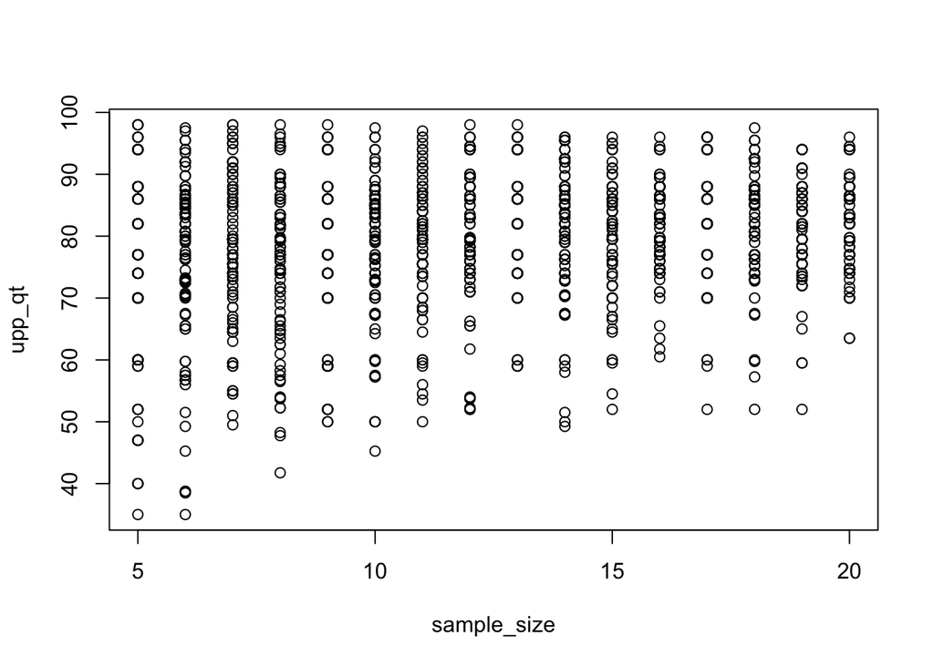

```r
plot(upp_qt ~ sample_size, data = vole_sim_quartiles)
```

# 4. SE and CI

#### 4a. With the upper quartile simulations, calculate the SD for each sample size using dplyr

```r
set.seed(2018)
#Take our vole_vaso upper quartile simulations
vole_quartiles <- vole_sim_quartiles %>%
#Group by each sample size
  group_by(sample_size) %>%
#calculate the SD of sample means
  summarize(sd_of_qt = sd(upp_qt))%>%
#turn into dataframe for use in part 4c.
  data.frame()%>%
  ungroup()
vole_quartiles
```

```
##    sample_size  sd_of_qt
## 1            5 15.032073
## 2            6 13.802860
## 3            7 12.147054
## 4            8 12.836726
## 5            9 11.761137
## 6           10 10.955667
## 7           11 10.296213
## 8           12 10.508660
## 9           13  8.970209
## 10          14 10.245588
## 11          15  9.160713
## 12          16  6.942427
## 13          17  8.640865
## 14          18  8.476581
## 15          19  7.455381
## 16          20  7.016343
```

#### 4b. What does this value, the standard error of the upper quartile, mean?

This shows the standard deviation of the upper quartile sampling distribution. The higher the sample number the lower the deviation in the sampling distribution.

#### 4c. What is the CI of the upper quartile with a sample size of 10. What does this mean?

The CI of the upper quartile with a sample size of 10 is within the following range:

76.07 < true value < 89.93 . This Confidence Interval indicates that we have 95% confidence that the true value of the mean of the upp qt falls within this range.

```r
#divide the sd of upper quartile when n = 10 by the sqrt of n = 10 to get the standard error

std_error_n10 <- vole_quartiles[6,2]/sqrt(10)

# Use the upper quartile value found in the beginning of question 3 to find the range for our 95% Confidence Interval

CI_Lower <- 83 - (2*std_error_n10)
CI_Upper <- 83 + (2*std_error_n10)

std_error_n10
```

```
## [1] 3.464486
```

```r
CI_Upper
```

```
## [1] 89.92897
```

```r
CI_Lower
```

```
## [1] 76.07103
```